# The Effect of Having a Daughter

Adrian Goedeckemeyer

10/15/2016

## Genetic Matching on the Washington (2008) case

To investigate wether having a daughter has an effect on decision making of members in the US House of Representative we are performing Genetic Matching on a Dataset aquired by sociologists in 2008.

We are controlling for several discrete variables (race, gender, political party, and religion) and continuous variables (seniority, age and Democratic vote share).

We will not be including demographic data of the legislators states (percentage females, college graduates), even though they are available in the dataset as they would introduce too many cofounders that are basically impossible to balance. A quick test (not included here) showed incredible low p-values when they were included. The democratic vote share variable will account for some of these indirectly, and we will perform sensitivity analysis on our best result to check how strong the influence of further covariates could be on our results.

The outcome variable measures the agreement of the representatives votes with positions of the National Organization of Women on a range from 0 to 100.

### Overview over the Data

```r
require(foreign)
require(Matching)
washington = read.dta('~/Downloads/basic.dta')
summary(washington)
```

```
##      year              congress         party          district
##  Length:1740        Min.   :105.0   Min.   :1.000   Min.   : 1.000
##  Class :character   1st Qu.:105.8   1st Qu.:1.000   1st Qu.: 3.000
##  Mode  :character   Median :106.5   Median :2.000   Median : 6.000
##                     Mean   :106.5   Mean   :1.525   Mean   : 9.999
##                     3rd Qu.:107.2   3rd Qu.:2.000   3rd Qu.:13.000
##                     Max.   :108.0   Max.   :3.000   Max.   :53.000
##
##    statenam             name               ngirls          nboys
##  Length:1740        Length:1740        Min.   :0.000   Min.   :0.000
##  Class :character   Class :character   1st Qu.:0.000   1st Qu.:0.000
##  Mode  :character   Mode  :character   Median :1.000   Median :1.000
##                                        Mean   :1.236   Mean   :1.209
##                                        3rd Qu.:2.000   3rd Qu.:2.000
##                                        Max.   :8.000   Max.   :6.000
##                                        NA's   :4       NA's   :4
##      totchi          anygirls        propgirls          rgroup
##  Min.   : 0.000   Min.   :0.0000   Min.   :0.0000   Min.   :0.000
##  1st Qu.: 2.000   1st Qu.:0.0000   1st Qu.:0.0000   1st Qu.:1.000
##  Median : 2.000   Median :1.0000   Median :0.5000   Median :1.000
##  Mean   : 2.445   Mean   :0.7149   Mean   :0.4453   Mean   :1.533
##  3rd Qu.: 3.000   3rd Qu.:1.0000   3rd Qu.:0.6667   3rd Qu.:2.000
##  Max.   :12.000   Max.   :1.0000   Max.   :1.0000   Max.   :4.000
##  NA's   :4        NA's   :4        NA's   :4
##    statabb             statalph        region              repub
##  Length:1740        Min.   : 1.00   Length:1740        Min.   :0.0000
##  Class :character   1st Qu.:11.00   Class :character   1st Qu.:0.0000
##  Mode  :character   Median :24.00   Mode  :character   Median :1.0000
##                     Mean   :25.02                      Mean   :0.5184
##                     3rd Qu.:38.00                      3rd Qu.:1.0000
##                     Max.   :51.00                      Max.   :1.0000
##
##      srvlng          female           white             bday
##  Min.   : 1.00   Min.   :0.0000   Min.   :0.0000   Min.   :1909-04-27
##  1st Qu.: 3.00   1st Qu.:0.0000   1st Qu.:1.0000   1st Qu.:1940-08-17
##  Median : 7.00   Median :0.0000   Median :1.0000   Median :1946-12-09
##  Mean   : 9.49   Mean   :0.1224   Mean   :0.8644   Mean   :1946-08-20
##  3rd Qu.:13.00   3rd Qu.:0.0000   3rd Qu.:1.0000   3rd Qu.:1953-03-10
##  Max.   :48.00   Max.   :1.0000   Max.   :1.0000   Max.   :1974-07-31
##
```

[output cut: 73 more lines]

```
##  Min.   :0.0000   Min.   :0.0000   Min.   :0.0000   Min.   :0.0000
##  1st Qu.:0.0000   1st Qu.:0.0000   1st Qu.:0.0000   1st Qu.:0.0000
##  Median :1.0000   Median :0.0000   Median :1.0000   Median :0.0000
##  Mean   :0.5731   Mean   :0.4548   Mean   :0.5777   Mean   :0.4919
##  3rd Qu.:1.0000   3rd Qu.:1.0000   3rd Qu.:1.0000   3rd Qu.:1.0000
##  Max.   :1.0000   Max.   :1.0000   Max.   :1.0000   Max.   :1.0000
##  NA's   :1309     NA's   :1309     NA's   :1309     NA's   :1309
##      now20
##  Min.   :0.0000
##  1st Qu.:0.0000
##  Median :0.0000
##  Mean   :0.4826
##  3rd Qu.:1.0000
##  Max.   :1.0000
##  NA's   :1309
```

```r
set.seed(123)
```

### Prepare Variables and Break up Key confounders

We are excluding all rows where no girl data was recorded, no score for agreement with the NOW calculated as well as the one third party member. As there is only one, we cannot achieve any balance on this member. This means we unfortunately loose one treated member, but it hopefully slightly improves the results (earlier tests showed that removing this datapoint raises the lowest p-value by about .1). I decided against just removing the third party variable, as that would mean higher complexity on party variables where one datapoint does not fit in like others.

```r
washington <- washington[!(is.na(washington$anygirls)) & !(is.na(washington$nowtot)) & !(washington$party == 3) ,]
attach(washington)

Y <- nowtot
Tr <- anygirls

p_dem <- party == 1
r_prot <- rgroup == 1
r_none <- rgroup == 0
r_cath <- rgroup == 2
r_christ <- rgroup == 3
r_other <- rgroup == 4
female <- female == 1
white <- white == 1

X <- cbind("democrat" = p_dem, "protestant" = r_prot, "nonreligious" = r_none, "catholic" = r_cath, "Other christian" = r_christ, "Other religion" = r_other, "White" = white, "Female" = female, "Democartic Vote Share" = demvote, "Length of Service" = srvlng, "Age" = age)
BalanceMat <- X
```

### Genetic Matching Attempt 1

```r
gmout <- GenMatch(Tr=Tr, X=X, BalanceMat=BalanceMat, estimand="ATT", pop.size=1000, max.generations = 500, wait.generations = 15)
```

[output not shown]

[output cut: 1976 more lines]

```
##  X[ 3] : 7.976846e+02
##  X[ 4] : 4.550606e+02
##  X[ 5] : 6.904234e+02
##  X[ 6] : 2.257856e+02
##  X[ 7] : 1.398284e+01
##  X[ 8] : 7.684145e+02
##  X[ 9] : 8.636081e+01
##  X[10] : 3.642556e+01
##  X[11] : 6.817076e+02
##
## Solution Found Generation 24
## Number of Generations Run 40
##
## Sun Oct 16 20:27:03 2016
## Total run time : 0 hours 3 minutes and 33 seconds
```

```r
match <- Match(Y=Y, Tr=Tr, X=X, Weight.matrix=gmout)
summary(match)
```

```
##
## Estimate...  0.86013
## AI SE......  2.2887
## T-stat.....  0.37582
## p.val......  0.70705
##
## Original number of observations..............  429
## Original number of treated obs...............  311
## Matched number of observations...............  311
## Matched number of observations  (unweighted).  313
```

```r
mb <- MatchBalance(Tr ~ p_dem + r_prot + r_none + r_cath + r_christ + r_other + white + female + demvote + srvlng + age, match.out=match, nboots=1000)
```

```
##
## ***** (V1) p_demTRUE *****
##                        Before Matching        After Matching
## mean treatment........    0.45981            0.45981
## mean control..........    0.50847            0.46302
## std mean diff.........    -9.7494           -0.64414
##
## mean raw eQQ diff.....   0.050847          0.0031949
## med  raw eQQ diff.....          0                  0
## max  raw eQQ diff.....          1                  1
##
## mean eCDF diff........   0.024334          0.0015974
## med  eCDF diff........   0.024334          0.0015974
## max  eCDF diff........   0.048668          0.0031949
##
## var ratio (Tr/Co).....    0.98858              0.999
## T-test p-value........    0.37023            0.56391
##
##
## ***** (V2) r_protTRUE *****
##                        Before Matching        After Matching
## mean treatment........    0.60772            0.60772
## mean control..........     0.5678            0.61093
## std mean diff.........     8.1629           -0.65749
##
## mean raw eQQ diff.....   0.033898          0.0031949
## med  raw eQQ diff.....          0                  0
## max  raw eQQ diff.....          1                  1
##
## mean eCDF diff........    0.01996          0.0015974
## med  eCDF diff........    0.01996          0.0015974
## max  eCDF diff........    0.03992          0.0031949
##
## var ratio (Tr/Co).....    0.96632              1.003
## T-test p-value........    0.45674            0.56391
##
##
## ***** (V3) r_noneTRUE *****
##                        Before Matching        After Matching
## mean treatment........   0.012862           0.012862
```

[output cut: 158 more lines]

```
## med  eCDF diff........   0.075862          0.0095847
## max  eCDF diff........    0.17731           0.044728
##
## var ratio (Tr/Co).....    0.71766             1.0519
## T-test p-value........  0.0020996            0.40784
## KS Bootstrap p-value..      0.005              0.826
## KS Naive p-value......   0.009226             0.9129
## KS Statistic..........    0.17731           0.044728
##
##
## Before Matching Minimum p.value: 0.0020996
## Variable Name(s): age  Number(s): 11
##
## After Matching Minimum p.value: 0.15697
## Variable Name(s): r_otherTRUE  Number(s): 6
```

### Genetic Matching Attempt 2

To improve on the previous model I will add some interaction variables and sqaured values.

```r
X <- cbind("democrat" = p_dem, "protestant" = r_prot, "nonreligious" = r_none, "catholic" = r_cath, "Other christian" = r_christ, "Other religion" = r_other, "White" = white, "Female" = female, "Democartic Vote Share" = demvote, "Length of Service" = srvlng, "Age" = age, "Age^2" = I(age^2), "Length of service^2" = I(srvlng^2), I(p_dem*demvote))
BalanceMat <- cbind("democrat" = p_dem, "protestant" = r_prot, "nonreligious" = r_none, "catholic" = r_cath, "Other christian" = r_christ, "Other religion" = r_other, "White" = white, "Female" = female, "Democartic Vote Share" = demvote, "Length of Service" = srvlng, "Age" = age)
gmout2 <- GenMatch(Tr=Tr, X=X, BalanceMat=BalanceMat, estimand="ATT", pop.size=1000, max.generations = 500, wait.generations = 15)
```

[output not shown]

[output cut: 1454 more lines]

```
##  X[ 6] : 3.897605e+02
##  X[ 7] : 2.649277e+00
##  X[ 8] : 9.177166e+02
##  X[ 9] : 9.035114e+01
##  X[10] : 5.881819e+01
##  X[11] : 1.715322e+02
##  X[12] : 4.471745e+02
##  X[13] : 1.251781e+02
##  X[14] : 6.712479e+02
##
## Solution Found Generation 7
## Number of Generations Run 23
##
## Sun Oct 16 20:29:15 2016
## Total run time : 0 hours 2 minutes and 10 seconds
```

```r
match2 <- Match(Y=Y, Tr=Tr, X=X, Weight.matrix=gmout2)
summary(match2)
```

```
##
## Estimate...  0.69132
## AI SE......  2.4289
## T-stat.....  0.28462
## p.val......  0.77593
##
## Original number of observations..............  429
## Original number of treated obs...............  311
## Matched number of observations...............  311
## Matched number of observations  (unweighted).  312
```

```r
mb <- MatchBalance(Tr ~ p_dem + r_prot + r_none + r_cath + r_christ + r_other + white + female + demvote + srvlng + age, match.out=match2, nboots=1000)
```

```
##
## ***** (V1) p_demTRUE *****
##                        Before Matching        After Matching
## mean treatment........    0.45981            0.45981
## mean control..........    0.50847            0.46302
## std mean diff.........    -9.7494           -0.64414
##
## mean raw eQQ diff.....   0.050847          0.0032051
## med  raw eQQ diff.....          0                  0
## max  raw eQQ diff.....          1                  1
##
## mean eCDF diff........   0.024334          0.0016026
## med  eCDF diff........   0.024334          0.0016026
## max  eCDF diff........   0.048668          0.0032051
##
## var ratio (Tr/Co).....    0.98858              0.999
## T-test p-value........    0.37023            0.56391
##
##
## ***** (V2) r_protTRUE *****
##                        Before Matching        After Matching
## mean treatment........    0.60772            0.60772
## mean control..........     0.5678            0.61093
## std mean diff.........     8.1629           -0.65749
##
## mean raw eQQ diff.....   0.033898          0.0032051
## med  raw eQQ diff.....          0                  0
## max  raw eQQ diff.....          1                  1
##
## mean eCDF diff........    0.01996          0.0016026
## med  eCDF diff........    0.01996          0.0016026
## max  eCDF diff........    0.03992          0.0032051
##
## var ratio (Tr/Co).....    0.96632              1.003
## T-test p-value........    0.45674            0.31731
##
##
## ***** (V3) r_noneTRUE *****
##                        Before Matching        After Matching
## mean treatment........   0.012862           0.012862
```

[output cut: 158 more lines]

```
## med  eCDF diff........   0.075862          0.0096154
## max  eCDF diff........    0.17731           0.048077
##
## var ratio (Tr/Co).....    0.71766             1.0328
## T-test p-value........  0.0020996            0.45014
## KS Bootstrap p-value..      0.004              0.703
## KS Naive p-value......   0.009226            0.86365
## KS Statistic..........    0.17731           0.048077
##
##
## Before Matching Minimum p.value: 0.0020996
## Variable Name(s): age  Number(s): 11
##
## After Matching Minimum p.value: 0.31731
## Variable Name(s): r_protTRUE r_noneTRUE r_otherTRUE femaleTRUE  Number(s): 2 3 6 8
```

### Genetic Matching Attempt 3:

```r
gmout3 <- GenMatch(Tr=Tr, X=X, BalanceMat=BalanceMat, estimand="ATT", pop.size=1000, max.generations = 500, wait.generations = 15, caliper = c(2,.5,2,2,2,.2,1,4,.4,.4,.3,.3,1,.6))
```

[output not shown]

[output cut: 2054 more lines]

```
##  X[ 6] : 7.531101e+02
##  X[ 7] : 5.093532e+02
##  X[ 8] : 8.488193e-01
##  X[ 9] : 3.489213e+02
##  X[10] : 6.184851e+02
##  X[11] : 9.632249e+02
##  X[12] : 6.246930e+02
##  X[13] : 1.208716e+02
##  X[14] : 9.763577e+02
##
## Solution Found Generation 17
## Number of Generations Run 33
##
## Sun Oct 16 20:32:00 2016
## Total run time : 0 hours 2 minutes and 44 seconds
```

```r
match3 <- Match(Y=Y, Tr=Tr, X=X, Weight.matrix=gmout3,caliper = c(2,.5,2,2,2,.2,1,4,.4,.4,.3,.3,1,.6))
summary(match3)
```

```
##
## Estimate...  -1.5766
## AI SE......  0.77675
## T-stat.....  -2.0297
## p.val......  0.042385
##
## Original number of observations..............  429
## Original number of treated obs...............  311
## Matched number of observations...............  111
## Matched number of observations  (unweighted).  111
##
## Caliper (SDs)........................................   2 0.5 2 2 2 0.2 1 4 0.4 0.4 0.3 0.3 1 0.6
## Number of obs dropped by 'exact' or 'caliper'  200
```

```r
mb3 <- MatchBalance(Tr ~ p_dem + r_prot + r_none + r_cath + r_christ + r_other + white + female + demvote + srvlng + age, match.out=match3, nboots=1000)
```

```
##
## ***** (V1) p_demTRUE *****
##                        Before Matching        After Matching
## mean treatment........    0.45981            0.27027
## mean control..........    0.50847            0.27027
## std mean diff.........    -9.7494                  0
##
## mean raw eQQ diff.....   0.050847                  0
## med  raw eQQ diff.....          0                  0
## max  raw eQQ diff.....          1                  0
##
## mean eCDF diff........   0.024334                  0
## med  eCDF diff........   0.024334                  0
## max  eCDF diff........   0.048668                  0
##
## var ratio (Tr/Co).....    0.98858                  1
## T-test p-value........    0.37023                  1
##
##
## ***** (V2) r_protTRUE *****
##                        Before Matching        After Matching
## mean treatment........    0.60772            0.77477
## mean control..........     0.5678            0.77477
## std mean diff.........     8.1629                  0
##
## mean raw eQQ diff.....   0.033898                  0
## med  raw eQQ diff.....          0                  0
## max  raw eQQ diff.....          1                  0
##
## mean eCDF diff........    0.01996                  0
## med  eCDF diff........    0.01996                  0
## max  eCDF diff........    0.03992                  0
##
## var ratio (Tr/Co).....    0.96632                  1
## T-test p-value........    0.45674                  1
##
##
## ***** (V3) r_noneTRUE *****
##                        Before Matching        After Matching
## mean treatment........   0.012862           0.009009
```

[output cut: 158 more lines]

```
## med  eCDF diff........   0.075862           0.018018
## max  eCDF diff........    0.17731           0.054054
##
## var ratio (Tr/Co).....    0.71766            0.91044
## T-test p-value........  0.0020996            0.58854
## KS Bootstrap p-value..      0.005              0.973
## KS Naive p-value......   0.009226            0.99691
## KS Statistic..........    0.17731           0.054054
##
##
## Before Matching Minimum p.value: 0.0020996
## Variable Name(s): age  Number(s): 11
##
## After Matching Minimum p.value: 0.58854
## Variable Name(s): age  Number(s): 11
```

The caliper greatly improves our matching balance up to .58 as the lowest p-value with 7 variables perfectly matched. Worst balance is achieved for Age. It is worth pointing out that neither treatment not control group include any members that identify as “Other Christian”, but this is not a big problem, as our full treatment group did not include any of this category either.

#### Some plots to illustrate the less balanced variables before and after matching:

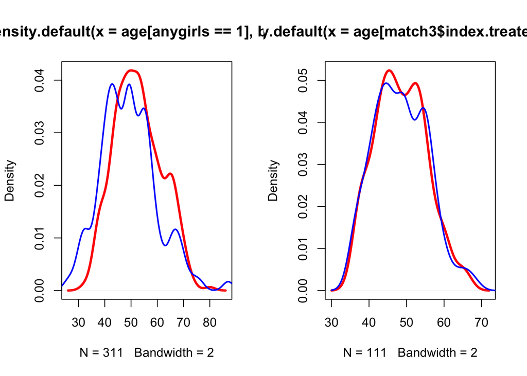

```r
par(mfrow = c(1,2))

plot(density(age[anygirls==1], bw = 2), lwd = 3, col = "red")
lines(density(age[anygirls==0], bw = 2), lwd = 2, col = "blue")

plot(density(age[match3$index.treated], bw = 2), lwd = 3, col = "red")
lines(density(age[match3$index.control], bw = 2), lwd = 2, col = "blue")
```

[figure not shown]

```r
plot(density(demvote[anygirls==1], bw = 2), lwd = 3, col = "red")
lines(density(demvote[anygirls==0], bw = 2), lwd = 2, col = "blue")

plot(density(demvote[match3$index.treated], bw = 2), lwd = 3, col = "red")
lines(density(demvote[match3$index.control], bw = 2), lwd = 2, col = "blue")
```

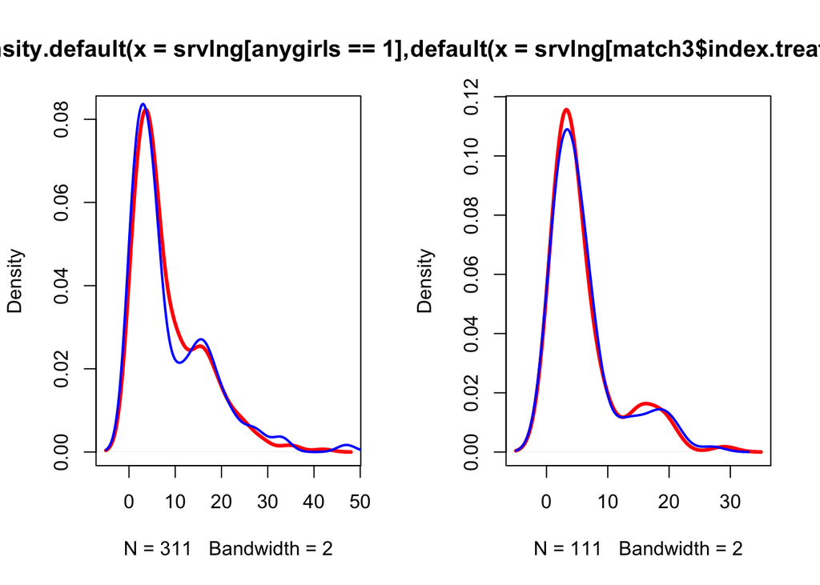

```r
plot(density(srvlng[anygirls==1], bw = 2), lwd = 3, col = "red")
lines(density(srvlng[anygirls==0], bw = 2), lwd = 2, col = "blue")

plot(density(srvlng[match3$index.treated], bw = 2), lwd = 3, col = "red")
lines(density(srvlng[match3$index.control], bw = 2), lwd = 2, col = "blue")
```

We will call these results satisfactory for now and continue to a sensitivity analysis:

### Sensitivity Analysis for the last results

```r
require(rbounds)
psens(match3, Gamma = 1.6, GammaInc = 0.05)
```

```
##
##  Rosenbaum Sensitivity Test for Wilcoxon Signed Rank P-Value
##
## Unconfounded estimate ....  0.3063
##
##  Gamma Lower bound Upper bound
##   1.00      0.3063      0.3063
##   1.05      0.2391      0.3805
##   1.10      0.1834      0.4556
##   1.15      0.1383      0.5289
##   1.20      0.1028      0.5982
##   1.25      0.0753      0.6620
##   1.30      0.0545      0.7193
##   1.35      0.0390      0.7696
##   1.40      0.0277      0.8129
##   1.45      0.0194      0.8497
##   1.50      0.0135      0.8803
##   1.55      0.0094      0.9056
##   1.60      0.0064      0.9261
##
##  Note: Gamma is Odds of Differential Assignment To
##  Treatment Due to Unobserved Factors
##
```

Generally we can’t be very happy with these Sensitivity Results, a p = 0.31 even when Gamma = 1 is a high value for odds of differential assignment due to an unobserved factor that has no influence on assignment. When Gamma rises we soon have much higher p-values.

#### Compared to Unmatched Tr vs Ctrl

```r
psens(x=nowtot[Tr==1], y=nowtot[Tr==0], Gamma = 1.6, GammaInc = 0.05)
```

```
##
##  Rosenbaum Sensitivity Test for Wilcoxon Signed Rank P-Value
##
## Unconfounded estimate ....  0.8418
##
##  Gamma Lower bound Upper bound
##   1.00      0.8418      0.8418
##   1.05      0.7403      0.9131
##   1.10      0.6193      0.9556
##   1.15      0.4914      0.9788
##   1.20      0.3695      0.9905
##   1.25      0.2637      0.9960
##   1.30      0.1790      0.9984
##   1.35      0.1158      0.9994
##   1.40      0.0717      0.9998
##   1.45      0.0426      0.9999
##   1.50      0.0243      1.0000
##   1.55      0.0134      1.0000
##   1.60      0.0072      1.0000
##
##  Note: Gamma is Odds of Differential Assignment To
##  Treatment Due to Unobserved Factors
##
```

These results are definitely much much worse though.

### Check Model Dependency (Optional and incomplete)

```r
#source('~/Downloads/modelDep.R')
#matched <- washington[!match3$index.dropped,]
#mdep0 <- modelDep( nowtot ~ p_dem + nboys + r_prot+r_none + r_cath + r_christ + r_other + white + female + demvote + srvlng + age, data=matched, tevar="anygirls")
#summary(mdep0$TE)
#plot(density(mdep0$TE, na.rm=TRUE), xlim=c(-4, 10),  main=sprintf("raw data, L1=%.3f, n=%d",imb$L1$L1,sum(summary(mod)$df[1:2])),xlab="TE estimate")
```